# Le jeu de rôle dans l'enseignement supérieur pour développer l'autonomie et la motivation des étudiants

## Laurent Brisson et Marine Karmann

https://perso.telecom-bretagne.eu/laurentbrisson/higher_education_pedagogy/jeu-de-role-qpes-2017/

## L’activité d’introduction avait pour but de vous mettre en situation professionnelle, évaluez votre intérêt pour cette activité

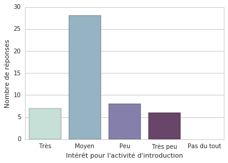

### En fonction de l'expérience professionnelle préalable

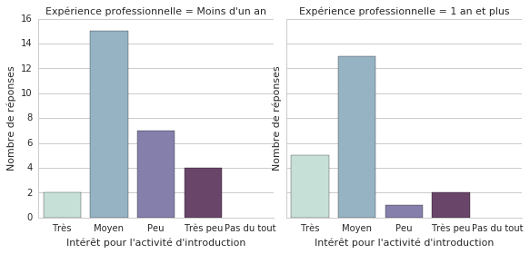

## A quel point jugez vous cette activité utile pour la suite de votre formation et/ou votre avenir professionnel ?

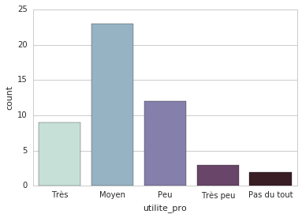

### En fonction de l'expérience professionnelle préalable

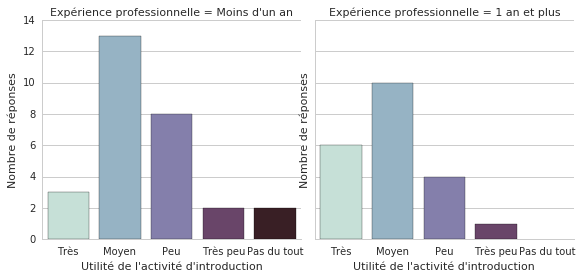

### En fonction de l'ancienneté des étudiants

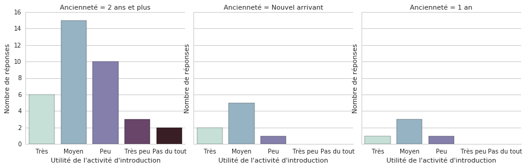

## Diriez-vous que l’activité d’introduction vous a été utile pour vous guider dans la mise en œuvre de votre projet de l’UV ?

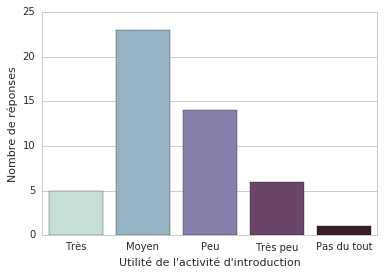

### En fonction de l'expérience professionnelle préalable

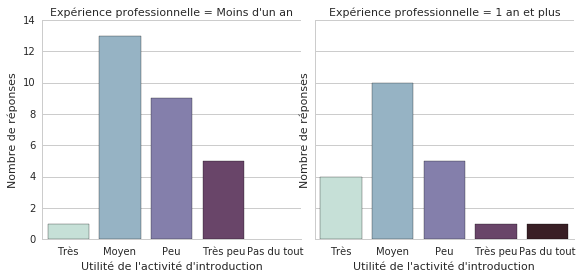

### Sélectionnez 3 items parmi les propositions suivantes

**Cette activité vous a permis de :**

- A - Apprendre à connaître des gens que je ne connaissais pas.
- B - Découvrir les compétences de mes camarades.
- C - Découvrir une façon différente de penser, de travailler (liée à une culture, une expérience professionnelle ou une formation différente).
- D - Apprendre à s’organiser pour être efficace en groupe, en temps contraint.
- E - Mettre à profit les compétences de chacun pour répondre à une commande.
- F - Apprendre à écouter les autres et à tirer parti des informations que l’on me donne.

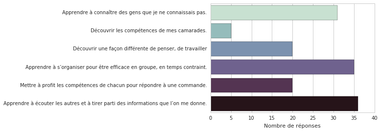

### Résultat consolidé à la question 5 : L'activité a-t-elle eu une influence sur la constitution de votre groupe ?

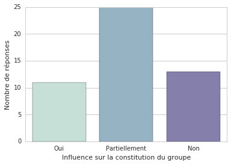

### En fonction du fait que l'étudiant soit ou non nouveau à l'école

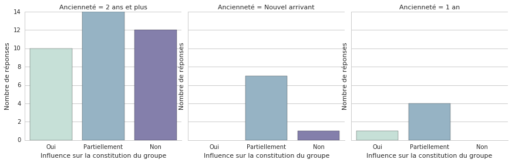

### En fonction du niveau de langue

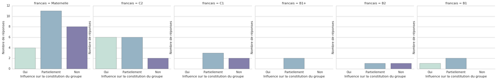

### En fonction du fait que le français soit la langue maternelle

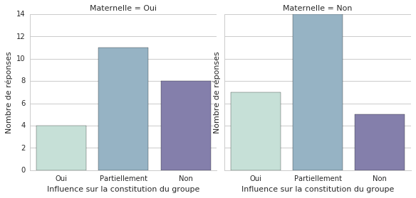

## Actuellement, diriez-vous que votre groupe travaille de manière efficace ?

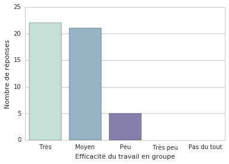

### En fonction de l'ancienneté de l'étudiant

[figure not shown]

## Statistiques globales sur la promotion ayant suivi l'enseignement

### Sexe

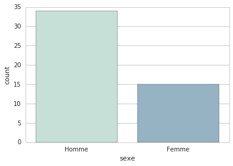

### Formation

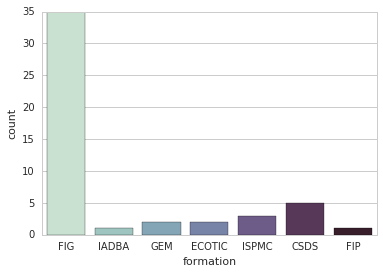

### Ancienneté

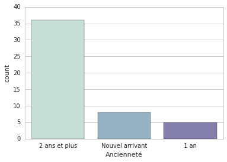

### Experience professionnelle

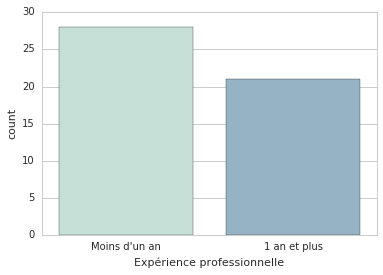

### En fonction du fait que le français soit la langue maternelle

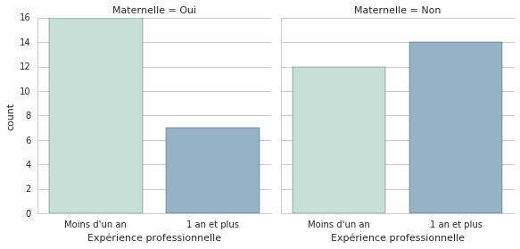

### Niveau de français

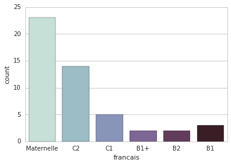